# Concrete_Featurization_Regression

```python
#import necessary python libraries
import numpy as np
from sklearn.linear_model import LinearRegression
import pandas as pd
import matplotlib.pyplot as plt
%matplotlib inline
import seaborn as sns
from sklearn.decomposition import PCA
from scipy.stats import zscore
from sklearn.svm import SVC
from sklearn.model_selection import train_test_split,KFold,GridSearchCV,cross_val_score,RandomizedSearchCV
from sklearn.metrics import mean_squared_error,r2_score
from sklearn.linear_model import LinearRegression, Lasso, Ridge
from sklearn.ensemble import RandomForestRegressor,GradientBoostingRegressor,AdaBoostRegressor
from sklearn.neighbors import KNeighborsRegressor
from sklearn.tree import DecisionTreeRegressor
from sklearn.preprocessing import PolynomialFeatures,StandardScaler
from xgboost import XGBRegressor
from sklearn.utils import resample
import xgboost
```

```python
#Load the dataset
concrete_df = pd.read_csv("https://raw.githubusercontent.com/vanjimohan/aiml/master/concrete.csv")
```

```python
concrete_df.head()
```

|  | cement | slag | ash | water | superplastic | coarseagg | fineagg | age | strength |
| --- | --- | --- | --- | --- | --- | --- | --- | --- | --- |
| 0 | 141.3 | 212.0 | 0.0 | 203.5 | 0.0 | 971.8 | 748.5 | 28 | 29.89 |
| 1 | 168.9 | 42.2 | 124.3 | 158.3 | 10.8 | 1080.8 | 796.2 | 14 | 23.51 |
| 2 | 250.0 | 0.0 | 95.7 | 187.4 | 5.5 | 956.9 | 861.2 | 28 | 29.22 |
| 3 | 266.0 | 114.0 | 0.0 | 228.0 | 0.0 | 932.0 | 670.0 | 28 | 45.85 |
| 4 | 154.8 | 183.4 | 0.0 | 193.3 | 9.1 | 1047.4 | 696.7 | 28 | 18.29 |

```python
#Check for missing values
concrete_df.isnull().sum()
```

```
cement          0
slag            0
ash             0
water           0
superplastic    0
coarseagg       0
fineagg         0
age             0
strength        0
dtype: int64
```

```python
concrete_df.describe().T
```

|  | count | mean | std | min | 25% | 50% | 75% | max |
| --- | --- | --- | --- | --- | --- | --- | --- | --- |
| cement | 1030.0 | 281.167864 | 104.506364 | 102.00 | 192.375 | 272.900 | 350.000 | 540.0 |
| slag | 1030.0 | 73.895825 | 86.279342 | 0.00 | 0.000 | 22.000 | 142.950 | 359.4 |
| ash | 1030.0 | 54.188350 | 63.997004 | 0.00 | 0.000 | 0.000 | 118.300 | 200.1 |
| water | 1030.0 | 181.567282 | 21.354219 | 121.80 | 164.900 | 185.000 | 192.000 | 247.0 |
| superplastic | 1030.0 | 6.204660 | 5.973841 | 0.00 | 0.000 | 6.400 | 10.200 | 32.2 |
| coarseagg | 1030.0 | 972.918932 | 77.753954 | 801.00 | 932.000 | 968.000 | 1029.400 | 1145.0 |
| fineagg | 1030.0 | 773.580485 | 80.175980 | 594.00 | 730.950 | 779.500 | 824.000 | 992.6 |
| age | 1030.0 | 45.662136 | 63.169912 | 1.00 | 7.000 | 28.000 | 56.000 | 365.0 |
| strength | 1030.0 | 35.817961 | 16.705742 | 2.33 | 23.710 | 34.445 | 46.135 | 82.6 |

```python
#Plot for Uni-variate  analysis:
def plot_distribution(data):
    f,(ax_box, ax_hist) = plt.subplots(2, sharex=True, gridspec_kw= {"height_ratios": (0.2, 1)})
    mean, median, mode = data.mean(), data.median(), data.mode().get_values()[0]

    sns.boxplot(data, ax=ax_box)
    ax_box.axvline(mean, color='r', linestyle='--')
    ax_box.axvline(median, color='g', linestyle='-')
    ax_box.axvline(mode, color='b', linestyle='-')

    sns.distplot(data,rug=True,ax=ax_hist)
    ax_hist.axvline(mean, color='r', linestyle='--')
    ax_hist.axvline(median, color='g', linestyle='-')
    ax_hist.axvline(mode, color='b', linestyle='-')
    plt.legend({'Mean':mean,'Median':median,'Mode':mode})
```

Uni-variate Analysis: Outliers are reprsented on corresponding boxplots. Histogram shows the distribution of each attribute along with its central values.

Cement: This column defines how much Kg of Cement is mixed in the concrete mixture. There are no missing values, the Mean(281) and 50% percentile-Median (273) are almost same. The difference between min value and first quartile is 90, however the difference bwn third quartile and max is high(190), so the distribution should have longer tail on the right side of the curve.

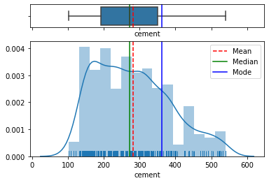

```python
plot_distribution(concrete_df['cement'])
```

Slag: Blast Furnace Slag is nonmetallic coproduct produced in the process of production of Iron. There are 471 values populated as zeros (0s). There could be chances that on these scenarios Slag might not be mixed in concrete so it is represented as 0 or else these are missing values? Min and first quartile values are 0 and there is huge difference(216.45) between 3rd quartile and max value. So there could be long tail in the right side of the distribution. Mean is 74 and median is 22, hence the distribution is not centred.

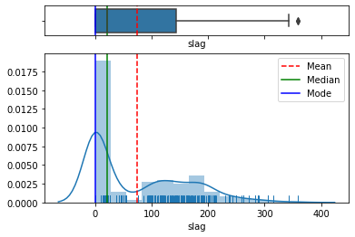

```python
plot_distribution(concrete_df['slag'])
```

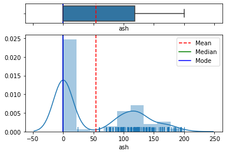

```python
plot_distribution(concrete_df['ash'])
```

water: Water is an essential component in concrete, so it is not having any zeros and no missing values. min -> 1st quartile is 43, 3rd quartile -> max value is 55. mean and median is almost closer. Hence the distribution could be kind of normal with minor outliers in the right side distribution.

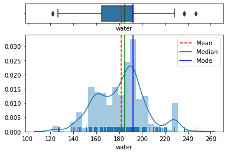

```python
plot_distribution(concrete_df['water'])
```

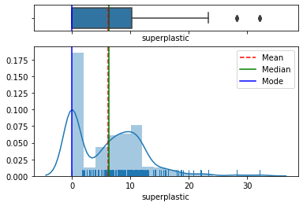

```python
plot_distribution(concrete_df['superplastic'])
```

coarseagg: Coarse aggregates are any particles greater than 0.19 inch, but generally range between 3/8 and 1.5 inches in diameter. Gravels constitute the majority of coarse aggregate used in concrete with crushed stone making up most of the remainder. There are no missing or 0 values. The distribution looks quite normal apart frm minor additional peaks.

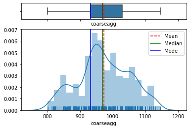

```python
plot_distribution(concrete_df['coarseagg'])
```

fineagg: Fine aggregates generally consist of natural sand or crushed stone with most particles passing through a 3/8-inch sieve. The distribution below is quite normal, Mean/Median is almost colloting each other. Some outliers represented on boxplot.

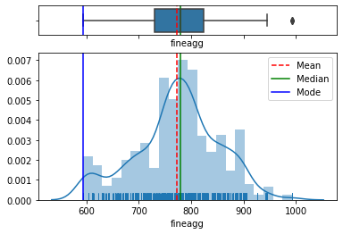

```python
plot_distribution(concrete_df['fineagg'])
```

age: Age is something how long the mixture is kept before applying on the building to assess the strengh of concrete. There are lot of concrete mixtures kept for very less days, very minimal studies made with longer age (since keeping it for longer days takes time for assessment, hence more studies would have been performed with lesser days). During bi-variate analysis we can see the relation between the age & strength if there is any contribution in keeping it for longer duration. There are lot of outliers found in right side of distribution due to the obvious reason that majority of studies made with lesser age.

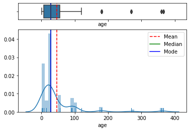

```python
plot_distribution(concrete_df['age'])
```

strength: This is our target variable, in the laboratory the compressive stregth of the given concrete is studied in Mega Pascal units. Concrete's compressive strength requirements can vary from 17 MPa for residential concrete to 28 MPa and higher in commercial structures. The distribution of strength is almost close to normal apart from few outliers in the right side of the curve. The central values are very close to each other (Mean, Median & Mode)

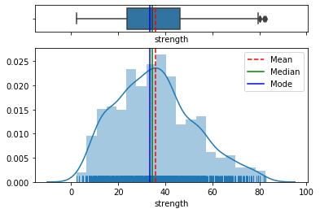

```python
plot_distribution(concrete_df['strength'])
```

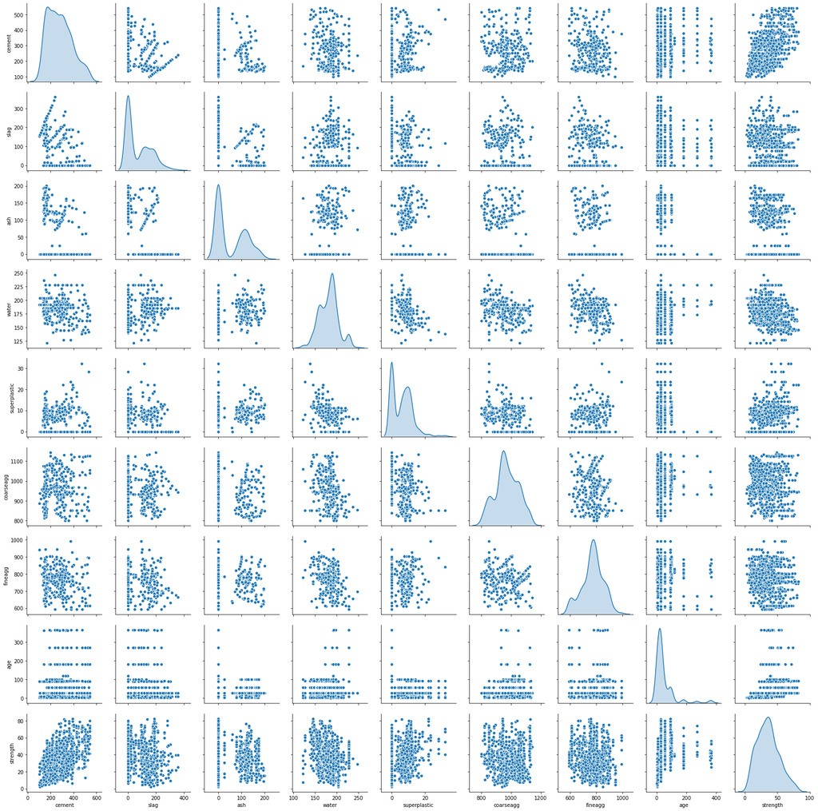

```python
#pair plot
sns.pairplot(concrete_df,diag_kind='kde')
```

Pairpanels help in understanding hte relation ship between the independent variables vs target variable. Basically for Bi-variate analysis. Cement is not having any linear relationship with any of the independent variables, most of thep data is scattered. However for the target variable it is kind of linear relationship for higher values of cement the higher the strength is observed.

Slag is not having any linear relationship with an yof the independent attributesm, all the distributions almost scattered. for the target variable the distribution is inconsistent there are very few points denotes the linear relationship at some instances irrespective of slag presence the strength varies (when it is 0, lot of variations in the strength), it could not be a major contributor for strengh.

ash is also not having any linear relationship with other independent variables. For the strength column the distribution is scattered kind of cloud.

water, when the water levels are low(around 150+ values )there are more strength observed. If concrete is too much watered it is not good close to 250 values the strength is not that great.

Superplastic it has good contribution for strength, when the higher values of superplastic the strength is increasing trend observed.

coarseagg, fineagg the plots with strength is almost scattered. there are very few values higher the value and higher the strength is observed.

age, most of the samples are taken with less age group. Only very few samples observed by keeping the mixture for longer duration. There are few instances higher the age value the strengh is more, but not up to the mark. The peak strength is observed with lesser age as well, hence it is not necessary to keep the concrete for longer duration like 200+ days.

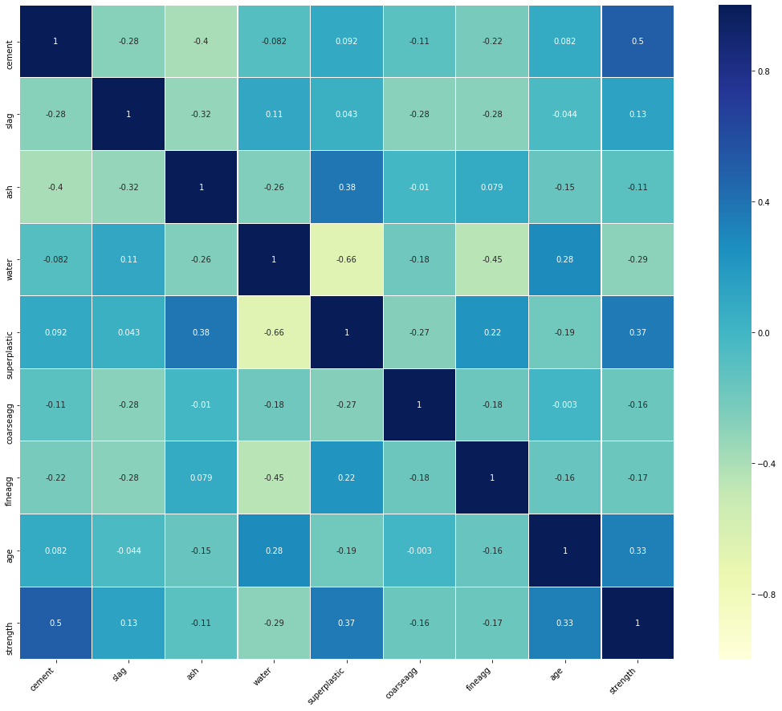

```python
corr = concrete_df.corr()
plt.subplots(figsize=(20,15))
ax = sns.heatmap(corr, vmin=-1, vmax=1, center=0,  square=True,cmap ="YlGnBu",linewidths = 0.1,annot=True)
ax.set_xticklabels(ax.get_xticklabels(), rotation=45, horizontalalignment='right');
```

cement, superplastic has good positive correlation with strength. Age has a correlation to certain extend.

```python
corr['strength'].abs().sort_values(ascending=False)
```

```
strength        1.000000
cement          0.497832
superplastic    0.366079
age             0.328873
water           0.289633
fineagg         0.167241
coarseagg       0.164935
slag            0.134829
ash             0.105755
Name: strength, dtype: float64
```

'ash','slag','coarseagg','fineagg' has very less correlation with Strength. If we are using linear model then these are the weak predictors for strength. Later point based on the random forest feature importances, the columns to exclude can be determined.

```python
#Handling Outliers:
#Scaling the dataset with zscore to apply box plot to identify the outliers
concrete_scaled = concrete_df.drop('strength', axis = 1).apply(zscore)
print("Shape before removing Outliers: ", concrete_scaled.shape)
concrete_filtered = concrete_df[(concrete_scaled < 3).all(axis=1)]
print("Shape after removing Outliers: ", concrete_filtered.shape)
print((concrete_scaled.shape[0] - concrete_filtered.shape[0]) ,"records removed due to outliers")
```

```
Shape before removing Outliers:  (1030, 8)
Shape after removing Outliers:  (981, 9)
49 records removed due to outliers
```

# Feature Engineering

Age column is represented in days with wide variety of data. Since majority of the values come in the lower range we can check whether it makes sense to cover them as months and have less classified values,

```python
#concrete_filtered['age_month'] = concrete_filtered['age'] / 30
#concrete_filtered['age_month'].head()
def getMonth(age):
    for month in range(1,12):
        if(age <= 30*month and age > 30*(month-1)):
            return month
    return 12
```

```python
concrete_df['age_month'] = concrete_df['age'].apply(lambda x:getMonth(x))
concrete_df[['age','age_month']].head(20)
```

|  | age | age_month |
| --- | --- | --- |
| 0 | 28 | 1 |
| 1 | 14 | 1 |
| 2 | 28 | 1 |
| 3 | 28 | 1 |
| 4 | 28 | 1 |
| 5 | 90 | 3 |
| 6 | 7 | 1 |
| 7 | 56 | 2 |
| 8 | 28 | 1 |
| 9 | 28 | 1 |
| 10 | 28 | 1 |
| 11 | 3 | 1 |
| 12 | 14 | 1 |
| 13 | 7 | 1 |
| 14 | 28 | 1 |
| 15 | 100 | 4 |
| 16 | 28 | 1 |
| 17 | 28 | 1 |
| 18 | 3 | 1 |
| 19 | 28 | 1 |

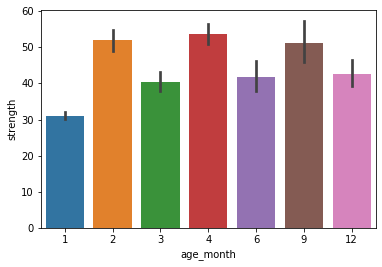

```python
sns.barplot(x=concrete_df['age_month'],y=concrete_df['strength'])
```

```python
#Finding Feature Importances using Random Forest Regressor
regressor = RandomForestRegressor(n_estimators = 100, random_state = 0)
target = 'strength'
X = concrete_filtered.drop(target,axis=1)
y = concrete_filtered[target]
regressor.fit(X,y)
```

```
RandomForestRegressor(bootstrap=True, criterion='mse', max_depth=None,
                      max_features='auto', max_leaf_nodes=None,
                      min_impurity_decrease=0.0, min_impurity_split=None,
                      min_samples_leaf=1, min_samples_split=2,
                      min_weight_fraction_leaf=0.0, n_estimators=100,
                      n_jobs=None, oob_score=False, random_state=0, verbose=0,
                      warm_start=False)
```

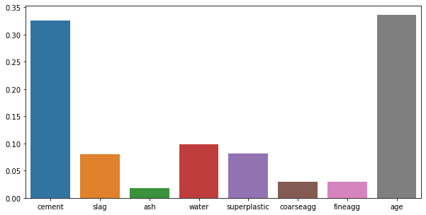

```python
plt.figure(figsize=(10,5))
sns.barplot(x=X.columns, y=regressor.feature_importances_)
```

```python
excluded = ['ash','coarseagg','fineagg']
concrete_excluded = concrete_filtered.drop(excluded,axis = 1)
print("Shape before excluding",concrete_filtered.shape)
print("Shape after excluding",concrete_excluded.shape)
```

```
Shape before excluding (981, 9)
Shape after excluding (981, 6)
```

# Modeling

```python
#Reusable method for adding result score
def addRow(df,ls):
    numEl = len(ls)
    newRow = pd.DataFrame(np.array(ls).reshape(1,numEl), columns = list(df.columns))
    df = df.append(newRow, ignore_index=True)
    return df
```

```python
#Reusable method to perform regressionMOdelling
def regressionModel(model, X,y,df):
    X_train, X_test, y_train, y_test = train_test_split(X, y, test_size=.30, random_state=0)
    model.fit(X_train, y_train)
    y_predict = model.predict(X_test)
    score = model.score(X_test, y_test)
    RMSE = np.sqrt(mean_squared_error(y_test, y_predict))
    r2 = r2_score(y_test, y_predict)
    df = addRow(df,[model.__class__.__name__, score, RMSE,r2])
    return df
```

```python
op_columns = ['model_name','score','RMSE','rSquared']
```

```python
#Trying various models
def doModelling(X,y):
    output_df = pd.DataFrame(columns = op_columns)
    model = LinearRegression()
    output_df = regressionModel(model,X,y,output_df)
    poly = PolynomialFeatures(degree = 2)
    X_poly = poly.fit_transform(X)
    output_df = regressionModel(model,X_poly,y,output_df)
    model = Lasso()
    output_df = regressionModel(model,X_poly,y,output_df)
    model = Ridge()
    output_df = regressionModel(model,X_poly,y,output_df)
    model = RandomForestRegressor(n_estimators=50)
    output_df = regressionModel(model,X_poly,y,output_df)
    model = GradientBoostingRegressor()
    output_df = regressionModel(model,X_poly,y,output_df)
    model = AdaBoostRegressor()
    output_df = regressionModel(model,X_poly,y,output_df)
    X_Z = X.apply(zscore)
    model = KNeighborsRegressor(n_neighbors= 3, weights = 'distance')
    output_df = regressionModel(model,X_Z,y,output_df)
    model = DecisionTreeRegressor()
    output_df = regressionModel(model,X_poly,y,output_df)
    model = XGBRegressor(objective ='reg:squarederror')
    output_df = regressionModel(model,X,y,output_df)
    xgboost.plot_importance(model)
    return output_df
```

|  | model_name | score | RMSE | rSquared |
| --- | --- | --- | --- | --- |
| 0 | LinearRegression | 0.6659395051061232 | 9.237221408829317 | 0.6659395051061232 |
| 1 | LinearRegression | 0.7835962581712654 | 7.43466109606115 | 0.7835962581712654 |
| 2 | Lasso | 0.7733554309470281 | 7.608542165316206 | 0.7733554309470281 |
| 3 | Ridge | 0.780784971319141 | 7.482796866301772 | 0.780784971319141 |
| 4 | RandomForestRegressor | 0.875044540035986 | 5.649453158411176 | 0.8750445400359861 |
| 5 | GradientBoostingRegressor | 0.8825988732063348 | 5.476018743243085 | 0.8825988732063347 |
| 6 | AdaBoostRegressor | 0.7919145429724852 | 7.290371469829376 | 0.7919145429724852 |
| 7 | KNeighborsRegressor | 0.7989448478518306 | 7.166158286649789 | 0.7989448478518306 |
| 8 | DecisionTreeRegressor | 0.7541149916289344 | 7.924918755932807 | 0.7541149916289344 |
| 9 | XGBRegressor | 0.8654830596403875 | 5.861614915446601 | 0.8654830596403875 |

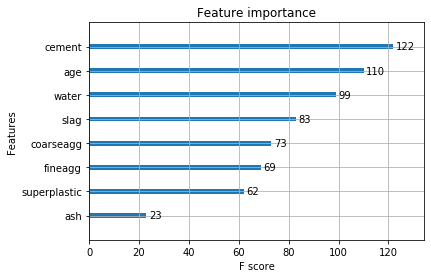

```python
doModelling(X,y)
```

Excluding decided columns and running same set of algorithms to find out the revised score,

|  | model_name | score | RMSE | rSquared |
| --- | --- | --- | --- | --- |
| 0 | LinearRegression | 0.650593980547555 | 9.447001507430684 | 0.650593980547555 |
| 1 | LinearRegression | 0.7557574172256445 | 7.898406570157944 | 0.7557574172256445 |
| 2 | Lasso | 0.7472964513509259 | 8.034048768703009 | 0.7472964513509259 |
| 3 | Ridge | 0.7557356756174548 | 7.898758106400363 | 0.7557356756174548 |
| 4 | RandomForestRegressor | 0.8589131639846467 | 6.003051102940867 | 0.8589131639846467 |
| 5 | GradientBoostingRegressor | 0.860170102173238 | 5.976250781775662 | 0.860170102173238 |
| 6 | AdaBoostRegressor | 0.78456041905089 | 7.418080487445977 | 0.78456041905089 |
| 7 | KNeighborsRegressor | 0.7864156120319066 | 7.386072149402219 | 0.7864156120319066 |
| 8 | DecisionTreeRegressor | 0.7541662840312864 | 7.924092131070594 | 0.7541662840312864 |
| 9 | XGBRegressor | 0.8600588945390832 | 5.97862678516365 | 0.8600588945390832 |

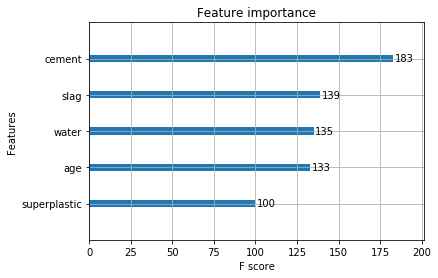

```python
X = concrete_excluded.drop(target,axis=1)
y = concrete_excluded[target]
doModelling(X,y)
```

There is 2 percent drop in the best score is close to 88%.

Best score is retrieved on GradientBoosting Regressor.However the score is almost same in XGBBooster & RandomForestRegressor as well. Hence let's try K-Fold Cross validation on these 3 algorithms.

```python
X = concrete_filtered.drop(target,axis=1)
y = concrete_filtered[target]
poly = PolynomialFeatures(degree = 2)
X_poly = poly.fit_transform(X)
```

```python
#K-Fold Cross Validation
def performKFold(model):
    kfold = KFold(n_splits=10, random_state=0)
    poly = PolynomialFeatures(degree = 2)
    X_poly = poly.fit_transform(X)
    res = cross_val_score(model, X_poly, y, cv=kfold)
    print("Model: ",model.__class__.__name__, "Score Mean: ",res.mean()*100.0, "Score Std: ", res.std()*100.0)
```

```python
performKFold(RandomForestRegressor(n_estimators=50))
performKFold(GradientBoostingRegressor())
performKFold(XGBRegressor(objective ='reg:squarederror'))
```

```
Model:  RandomForestRegressor Score Mean:  90.84107952457407 Score Std:  2.22658485246422
Model:  GradientBoostingRegressor Score Mean:  90.95381772606277 Score Std:  2.2072945478200157
```

```
Model:  XGBRegressor Score Mean:  91.18363903377252 Score Std:  2.1007630929868113
```

```python
GB_param_dist = {'learning_rate':[0.15,0.1,0.05,0.01,0.005,0.001], 'n_estimators':[100,250,500,750,1000,1250,1500,1750]}
model = GradientBoostingRegressor()
print(model)
rGrid = RandomizedSearchCV(model, param_distributions=GB_param_dist,n_iter=20, cv=10)
poly = PolynomialFeatures(degree = 2)
X_poly = poly.fit_transform(X)
rGrid.fit(X_poly, y)
print(rGrid.best_params_)
params = rGrid.best_params_
```

```
GradientBoostingRegressor(alpha=0.9, criterion='friedman_mse', init=None,
                          learning_rate=0.1, loss='ls', max_depth=3,
                          max_features=None, max_leaf_nodes=None,
                          min_impurity_decrease=0.0, min_impurity_split=None,
                          min_samples_leaf=1, min_samples_split=2,
                          min_weight_fraction_leaf=0.0, n_estimators=100,
                          n_iter_no_change=None, presort='auto',
                          random_state=None, subsample=1.0, tol=0.0001,
                          validation_fraction=0.1, verbose=0, warm_start=False)
{'n_estimators': 1000, 'learning_rate': 0.15}
```

```python
X_train, X_test, y_train, y_test = train_test_split(X_poly, y, test_size=.30, random_state=0)
model = GradientBoostingRegressor(n_estimators=1750, learning_rate=0.05)
model.fit(X_train, y_train)
y_predict = model.predict(X_test)
score = model.score(X_test, y_test)
RMSE = np.sqrt(mean_squared_error(y_test, y_predict))
print("Model: ","GradientBoostingRegressor ","Score: ",score," RMSE: ",RMSE)
```

```
Model:  GradientBoostingRegressor  Score:  0.9058327793047007  RMSE:  4.904318533262152
```

```python
#Finding 95% confidence level through Bootstraping
n_iterations = 100           # Number of bootstrap samples to create (Since the machine is slow ran for 100 times, otherwise ideal to run for around 1000 times)
n_size = int(len(concrete_filtered) * 0.50)    # picking only 50 % of the given data in every bootstrap sample
# run bootstrap
stats = list()
values = concrete_filtered.values
for i in range(n_iterations):
	# prepare train and test sets
	train = resample(values, n_samples=n_size)  # Sampling with replacement
	test = np.array([x for x in values if x.tolist() not in train.tolist()])  # picking rest of the data not considered in sample
    # fit model
	model = GradientBoostingRegressor(n_estimators=params['n_estimators'], learning_rate=params['learning_rate']) # Model based on Hyper param tuning
	model.fit(train[:,:-1], train[:,-1])
    # evaluate model
	predictions = model.predict(test[:,:-1])
	score = r2_score(test[:,-1], predictions)
	stats.append(score)
```

[output not shown]

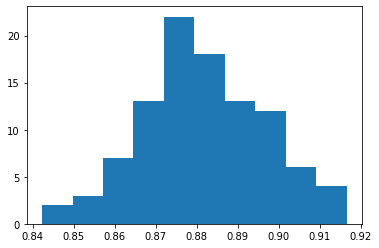

```python
# plot scores
plt.hist(stats)
# confidence intervals
alpha = 0.95                             # for 95% confidence
p = ((1.0-alpha)/2.0) * 100              # tail regions on right and left .25 on each side indicated by P value (border)
lower = max(0.0, np.percentile(stats, p))
p = (alpha+((1.0-alpha)/2.0)) * 100
upper = min(1.0, np.percentile(stats, p))
print('%.1f confidence interval %.1f%% and %.1f%%' % (alpha*100, lower*100, upper*100))
```

[output not shown]